# Exploratory analysis for memorability of food stimuli

Xinyue Li

11/30/2020

## Set up

The food folios data is filtered by age (18-35). Same as what mentioned in the paper, we will also flip 4 of the measures:

Sugar-low sugar

Disgusting-not disgusting

Healthy-unhealthy

Vitamins-low vitamins

(All of the following codes are based on source code by Shehzad on github: [github.com/czarrar/food_choice](https://github.com/czarrar/food_choice/blob/main/20_factor_scores.Rmd))

```r
rdat = dat.f %>% dplyr::select(stimulus, choice.rating, starts_with("rating"))
colnames(rdat) = sub("rating[.]", "", colnames(rdat))
colnames(rdat) = sub("[.]rating", "", colnames(rdat))

rdat$sugar = 10 - rdat$sugar
rdat$disgusting = 10 - rdat$disgusting
rdat$healthy = 10 - rdat$healthy
rdat$vitamins = 10 - rdat$vitamins

# rename
cinds = sapply(c("sugar", "disgusting", "healthy", "vitamins"), function(x) which(colnames(rdat) == x))
colnames(rdat)[cinds] = c("low-sugar", "not-disgusting", "unhealthy", "low-vitamins")

rmat = as.matrix(rdat[,-1])
rownames(rmat) = rdat$stimulus
rmat.nochoice = rmat[,-1]
```

## Correlation Matrix

Correlation Matrix of filtered original data and memorability score The patterns of ratings are roughly the same as the correlation matrix in the manuscript. Memorability showed positive correlation with **tasty**, **other tasty**, **feel**, which are major loadings for the factor **tasty** analyzed in the manuscript.

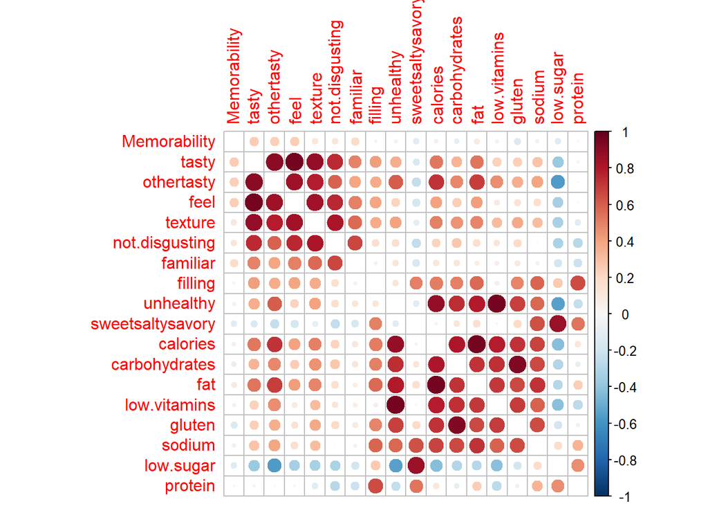

```r
# average of ratings for each image
# follow the order of values on paper
new.ord = c("tasty", "othertasty", "feel", "texture", "not-disgusting", "familiar", "filling", "unhealthy", "sweetsaltysavory", "calories", "carbohydrates", "fat", "low-vitamins", "gluten", "sodium", "low-sugar", "protein", "stimulus")

# correlation matrix with memorability score
ave.mat.r = rdat[,new.ord] %>%
  group_by(stimulus) %>%
  summarise_all(mean)
# matching memorability stimulus name to food data stimulus name
ave.mat.r = data.frame(Memorability = name$Memorability, mem.stimulus = name$X, ave.mat.r)

M.mem = ave.mat.r %>% dplyr::select(-mem.stimulus, -stimulus) %>% cor()
diag(M.mem) = 0
corrplot(M.mem, method="circle", diag = F, #order="hclust",
         #is.corr=F, cl.lim=c(-0.85,0.85),
         col=rev(colorRampPalette(brewer.pal(n=11, name="RdBu"))(256)))
```

# Factor Analysis

Run factor analysis with the filtered food data. The results are the same as the original dataset. There are 3 factors,and the loads of factors are showing same pattern as the paper showed.

Three factors are named as: **Tasty, Healthiness, and Savory**.

Plot loading of ratings to the three factors with the filtered data.

```r
# factor analysis
nFactors::nCng(as.data.frame(rmat.nochoice), model="factors")
```

```
## [1] 3
```

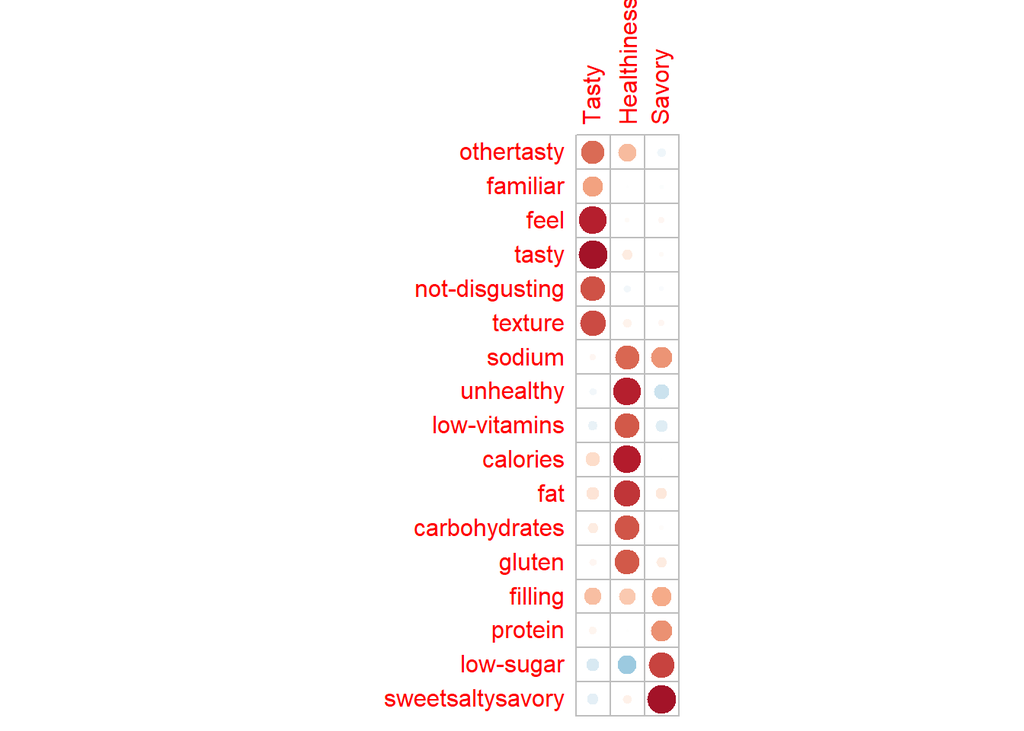

```r
fit <- factanal(rmat.nochoice, 3, scores="regression")

d <- dist(fit$loadings)
hc <- hclust(d, method="average")
dend <- as.dendrogram(hc)
loads <- fit$loadings[order.dendrogram(dend),]
loads <- rbind(choice=loads[rownames(loads) == "choice",], loads[rownames(loads) != "choice",])
# Make tasty first, then health, and finally sweet/savory
loads2 <- loads[,c(2,1,3)]
colnames(loads2) <- sprintf("Factor-%i", 1:3)
# Put the sweet/savory to the end
loads2 <- rbind(loads2[-c(1:4),], loads2[1:4,])
colnames(loads2) = c("Tasty", "Healthiness", "Savory")
# Plot
 cols2 <- colorRampPalette(c("#67001F", "#B2182B", "#D6604D",
                            "#F4A582", "#FDDBC7", "#FFFFFF", "#D1E5F0", "#92C5DE", "#4393C3", "#2166AC", "#053061"))(200)
corrplot::corrplot(loads2, diag=T, col=rev(cols2), cl.pos="n")
```

## Multiple Regression

The multiple regression result showed that **tasty** is the only factor that can predict memorability.

Show as the plot below:

```r
scores3 <- fit$scores
ind1 <- which.max(fit$loadings[rownames(fit$loadings) == "unhealthy",])
ind2 <- which.max(fit$loadings[rownames(fit$loadings) == "tasty",])
ind3 <- which.max(fit$loadings[rownames(fit$loadings) == "sweetsaltysavory",])
colnames(scores3) <- c("Food.UnHealth", "Food.Taste", "Food.SweetProtein")[c(ind1,ind2,ind3)]
outdf <- data.frame(subjectId=dat.f$subjectId, stimulus=dat.f$stimulus, scores3)

# score of factor for each food item
ave.factor = outdf %>% group_by(stimulus) %>%
  summarise_all(mean)

# add mem score to the factor data frame
labels = sapply(name$stimulus, function(x) which(ave.factor$stimulus == x))
ave.factor.mem = data.frame(Memorability = name$Memorability, mem.stimulus = name$X, ave.factor)

# perform linear regression
fit1 = lm(Memorability ~ Food.Taste + Food.UnHealth + Food.SweetProtein, data = ave.factor.mem)
summary(fit1)
```

```
##
## Call:
## lm(formula = Memorability ~ Food.Taste + Food.UnHealth + Food.SweetProtein,
##     data = ave.factor.mem)
##
## Residuals:
##      Min       1Q   Median       3Q      Max
## -0.44522 -0.08272 -0.00199  0.08395  0.36138
##
## Coefficients:
##                    Estimate Std. Error t value Pr(>|t|)
## (Intercept)        0.471386   0.010631  44.342  < 2e-16 ***
## Food.Taste         0.083719   0.028708   2.916  0.00416 **
## Food.UnHealth     -0.008651   0.014046  -0.616  0.53901
## Food.SweetProtein -0.008285   0.014440  -0.574  0.56708
## ---
## Signif. codes:  0 '***' 0.001 '**' 0.01 '*' 0.05 '.' 0.1 ' ' 1
##
## Residual standard error: 0.1249 on 134 degrees of freedom
## Multiple R-squared:  0.06928,    Adjusted R-squared:  0.04844
## F-statistic: 3.325 on 3 and 134 DF,  p-value: 0.02172
```

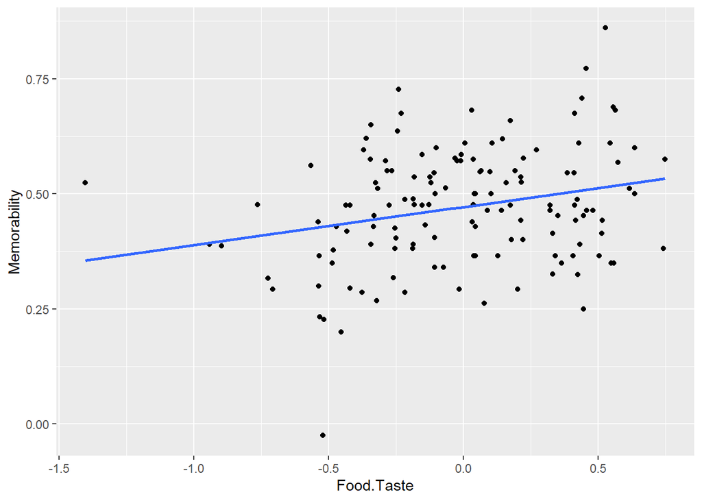

```r
# plot mem~food.taste
ave.factor.mem %>% ggplot(aes(x = Food.Taste, y = Memorability))+
  geom_point()+
  geom_smooth(method='lm', se = FALSE)
```

## Explore correlations

```r
# correlation between memorability and heathiness
cor.test(ave.factor.mem$Memorability, ave.factor.mem$Food.UnHealth)
```

```
##
##  Pearson's product-moment correlation
##
## data:  ave.factor.mem$Memorability and ave.factor.mem$Food.UnHealth
## t = 0.096907, df = 136, p-value = 0.9229
## alternative hypothesis: true correlation is not equal to 0
## 95 percent confidence interval:
##  -0.1590162  0.1751710
## sample estimates:
##         cor
## 0.008309388
```

```r
# correlation between memorability and Savory
cor.test(ave.factor.mem$Memorability, ave.factor.mem$Food.SweetProtein)
```

```
##
##  Pearson's product-moment correlation
##
## data:  ave.factor.mem$Memorability and ave.factor.mem$Food.SweetProtein
## t = -1.181, df = 136, p-value = 0.2397
## alternative hypothesis: true correlation is not equal to 0
## 95 percent confidence interval:
##  -0.26342546  0.06748521
## sample estimates:
##        cor
## -0.1007559
```

```r
# correlation between memorability and choice preference
rdat.mean = rdat %>% group_by(stimulus)%>%  summarise_all(mean)
rdat.mean = data.frame(Memorability = name$Memorability, mem.stimulus = name$X, rdat.mean)
cor.test(rdat.mean$Memorability, rdat.mean$choice)
```

```
##
##  Pearson's product-moment correlation
##
## data:  rdat.mean$Memorability and rdat.mean$choice
## t = 2.033, df = 136, p-value = 0.04399
## alternative hypothesis: true correlation is not equal to 0
## 95 percent confidence interval:
##  0.004773882 0.329393334
## sample estimates:
##       cor
## 0.1717417
```

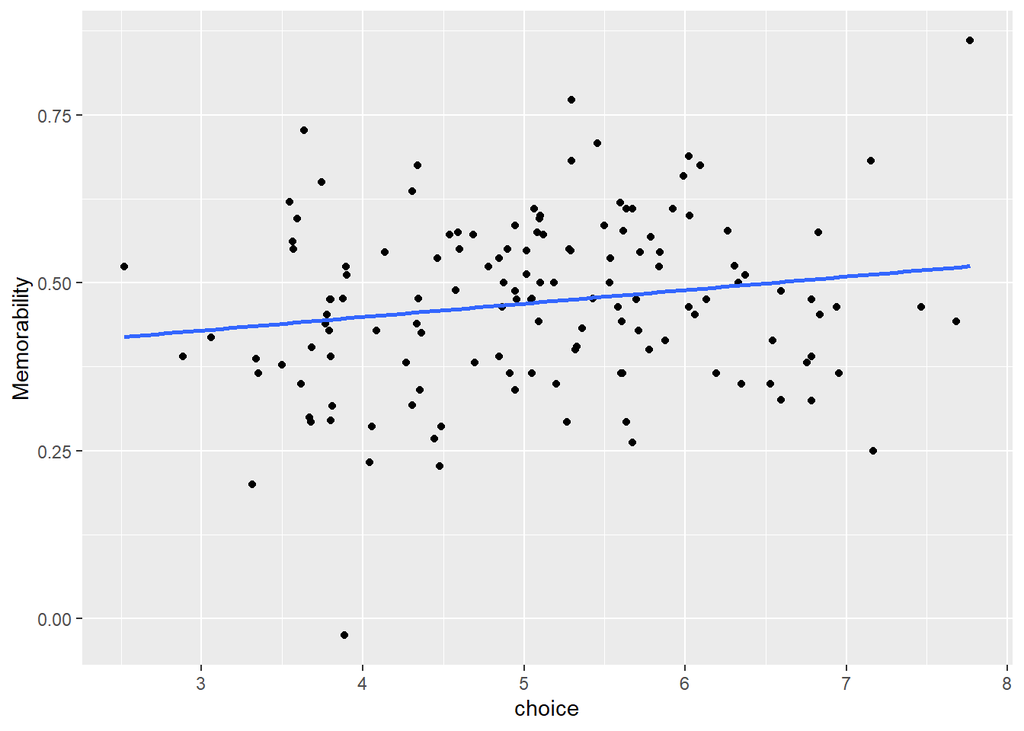

```r
# plot memorability and preference choice
rdat.mean %>% ggplot(aes(x = choice, y = Memorability))+
  geom_point()+
  geom_smooth(method='lm', se = FALSE)
```

## Factor analysis with memorability

```r
# include memorability in factor analysis
ave.mat.r.nostimulus = ave.mat.r %>% dplyr::select(-mem.stimulus, -stimulus)
nFactors::nCng(as.data.frame(ave.mat.r.nostimulus), model="factors")
```

```
## [1] 3
```

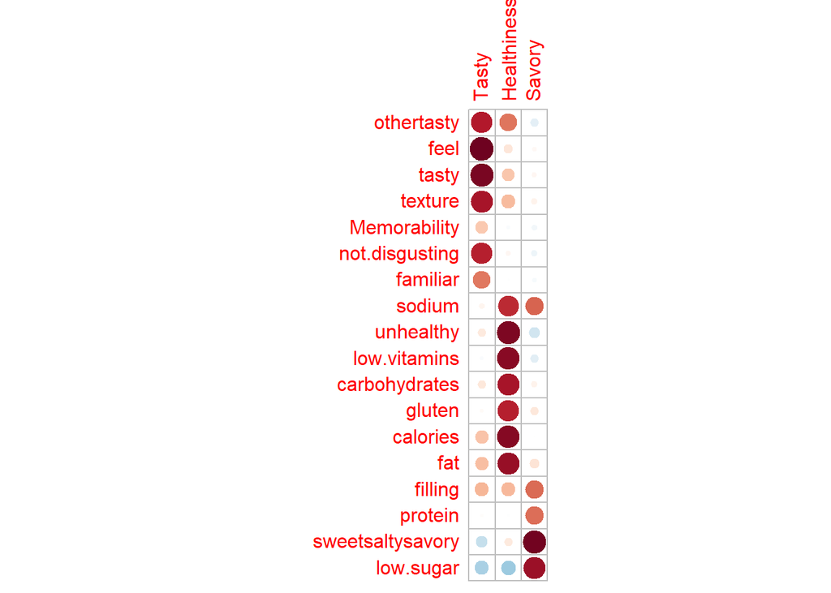

```r
fit.m <- factanal(ave.mat.r.nostimulus, 3, scores="regression")

d.m <- dist(fit.m$loadings)
hc.m <- hclust(d.m, method="average")
dend.m <- as.dendrogram(hc.m)
loads.m <- fit.m$loadings[order.dendrogram(dend.m),]
loads.m <- rbind(choice=loads.m[rownames(loads.m) == "choice",], loads.m[rownames(loads.m) != "choice",])
# Make tasty first, then health, and finally sweet/savory
loads2.m <- loads.m[,c(2,1,3)]
colnames(loads2.m) <- sprintf("Factor-%i", 1:3)
# Put the sweet/savory to the end
loads2.m <- rbind(loads2.m[-c(1:4),], loads2.m[1:4,])
colnames(loads2.m) = c("Tasty", "Healthiness", "Savory")
# Plot
corrplot::corrplot(loads2.m, diag=T, col=rev(cols2), cl.pos="n")
```

## Physical Properties of the Images

**No significance** found between memorabillity and low level perceptural properties of the images.

```r
dat.name = read.csv("label_and_image_name.csv")
dat.physical = read.csv("physical_image_properties.csv")
physical.mem = cbind(dat.name, dat.physical, ave.factor.mem)

# correlation between memorability and R/G/B
cor.test(physical.mem$Memorability, physical.mem$Red)
```

```
##
##  Pearson's product-moment correlation
##
## data:  physical.mem$Memorability and physical.mem$Red
## t = 0.87016, df = 136, p-value = 0.3857
## alternative hypothesis: true correlation is not equal to 0
## 95 percent confidence interval:
##  -0.09386324  0.23854742
## sample estimates:
##        cor
## 0.07440869
```

```r
cor.test(physical.mem$Memorability, physical.mem$Green)
```

```
##
##  Pearson's product-moment correlation
##
## data:  physical.mem$Memorability and physical.mem$Green
## t = 0.84645, df = 136, p-value = 0.3988
## alternative hypothesis: true correlation is not equal to 0
## 95 percent confidence interval:
##  -0.09587284  0.23663404
## sample estimates:
##        cor
## 0.07239177
```

```r
cor.test(physical.mem$Memorability, physical.mem$Blue)
```

```
##
##  Pearson's product-moment correlation
##
## data:  physical.mem$Memorability and physical.mem$Blue
## t = -1.0284, df = 136, p-value = 0.3056
## alternative hypothesis: true correlation is not equal to 0
## 95 percent confidence interval:
##  -0.25125784  0.08044452
## sample estimates:
##         cor
## -0.08784114
```

```r
# correlation between memorability and intensity
cor.test(physical.mem$Memorability, physical.mem$Intensity)
```

```
##
##  Pearson's product-moment correlation
##
## data:  physical.mem$Memorability and physical.mem$Intensity
## t = -0.87877, df = 136, p-value = 0.3811
## alternative hypothesis: true correlation is not equal to 0
## 95 percent confidence interval:
##  -0.23924180  0.09313327
## sample estimates:
##         cor
## -0.07514099
```

```r
# correlation between memorability and complexity
cor.test(physical.mem$Memorability, physical.mem$Normalized.complexity)
```

```
##
##  Pearson's product-moment correlation
##
## data:  physical.mem$Memorability and physical.mem$Normalized.complexity
## t = 1.4102, df = 136, p-value = 0.1608
## alternative hypothesis: true correlation is not equal to 0
## 95 percent confidence interval:
##  -0.04801931  0.28150643
## sample estimates:
##       cor
## 0.1200488
```

## Clustering Analysis

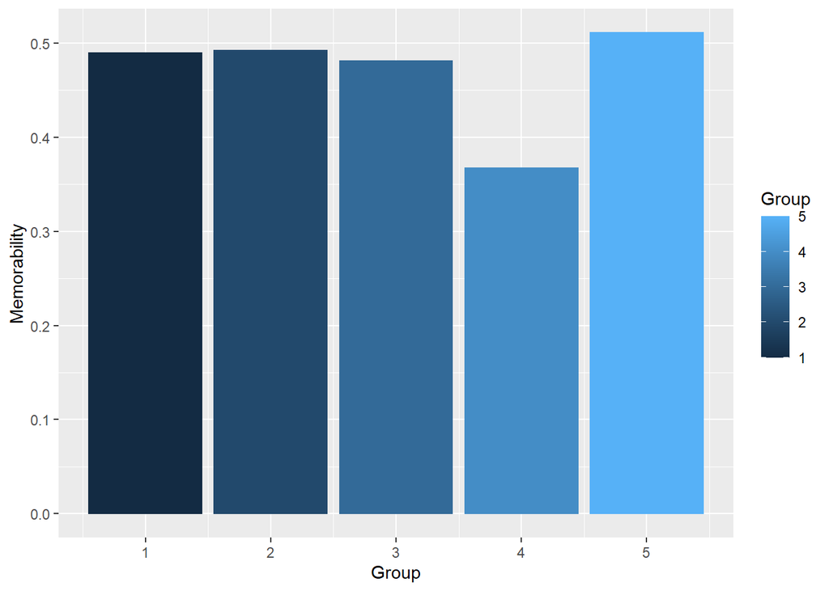

```r
# K-Means Cluster Analysis
kmeans.data = ave.factor.mem %>% dplyr::select(-mem.stimulus, -subjectId, -stimulus)
fit = kmeans(kmeans.data, 5) # 5 cluster solution
# get cluster means
cluster.means = aggregate(kmeans.data,by=list(fit$cluster),FUN=mean)
# barplots for means
# cluster.means %>% group_by(Group.1) %>% mutate(Group = Group.1) %>%
# ggplot( aes(y = Food.UnHealth, x = Group)) +
#   geom_bar(aes(color = Group, fill = Group),
#                 stat = "identity")
# cluster.means %>% group_by(Group.1) %>% mutate(Group = Group.1) %>%
# ggplot( aes(y = Food.Taste, x = Group)) +
#   geom_bar(aes(color = Group, fill = Group),
#                 stat = "identity")
# cluster.means %>% group_by(Group.1) %>% mutate(Group = Group.1) %>%
# ggplot( aes(y = Food.SweetProtein, x = Group)) +
#   geom_bar(aes(color = Group, fill = Group),
#                 stat = "identity")
cluster.means %>% group_by(Group.1) %>% mutate(Group = Group.1) %>%
ggplot( aes(y = Memorability, x = Group)) +
  geom_bar(aes(color = Group, fill = Group),
                stat = "identity")
```

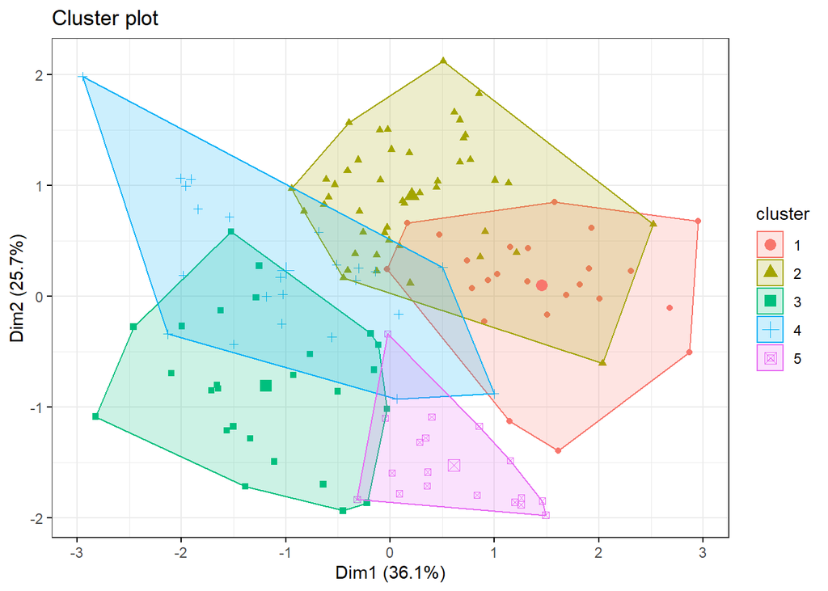

```r
# append cluster assignment
kmeans.data = data.frame(kmeans.data, fit$cluster)

# plot
fviz_cluster(fit, data = kmeans.data[, -5],
             # palette = c("#2E9FDF", "#00AFBB", "#E7B800"),
             geom = "point",
             ellipse.type = "convex",
             ggtheme = theme_bw()
             )
```

## Clustering analysis without memorability

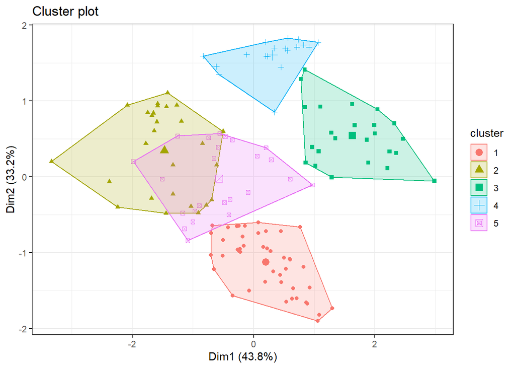

```r
# K-Means Cluster Analysis
kmeans.data.no = ave.factor.mem %>% dplyr::select(-mem.stimulus, -subjectId, -stimulus, -Memorability)
fit.no.mem = kmeans(kmeans.data.no, 5) # 5 cluster solution
# get cluster means
cluster.means.no = aggregate(kmeans.data.no,by=list(fit.no.mem$cluster),FUN=mean)

# cluster.means.no %>% group_by(Group.1) %>% mutate(Group = Group.1) %>%
# ggplot( aes(y = Food.UnHealth, x = Group)) +
#   geom_bar(aes(color = Group, fill = Group),
#                 stat = "identity")
# cluster.means.no %>% group_by(Group.1) %>% mutate(Group = Group.1) %>%
# ggplot( aes(y = Food.Taste, x = Group)) +
#   geom_bar(aes(color = Group, fill = Group),
#                 stat = "identity")
# cluster.means.no %>% group_by(Group.1) %>% mutate(Group = Group.1) %>%
# ggplot( aes(y = Food.SweetProtein, x = Group)) +
#   geom_bar(aes(color = Group, fill = Group),
#                 stat = "identity")


# append cluster assignment
kmeans.data = data.frame(kmeans.data.no, fit.no.mem$cluster)

# plot
fviz_cluster(fit.no.mem, data = kmeans.data.no,
             # palette = c("#2E9FDF", "#00AFBB", "#E7B800"),
             geom = "point",
             ellipse.type = "convex",
             ggtheme = theme_bw()
             )
```